# Отчет Рябова А.А. по тестовому заданию на соискание должности исследователя "Белка Диджитал"

## Постановка задачи

Необходимо для данных с сайта www.citystar.ru, содержащего объявления о продажи квартир в Магнитогорске, построить математическую модель стоимости жилья в зависимости от параметров этого жилья. Вид задачи регрессия.

Пример объявлений на сайте:

[figure not shown]

## Выбор и получение исходных данных

Для получения объявлений о продажи квартир с сайта применялся парсинг.

Проведя анализ адреса URL сайта было замечено, что для каждой станицы с объявлениями базовая часть URL сохраняется. Изменяется лишь конечный параметр "&pN=", его значение равно номеру запрашиваемой странице.

Также анализирую HTML-разметку сайта было замечено, что каждое объявление содержится в теге "tr" имеющий класс "tbb". Каждый параметр объявления (фото, дата, тип квартиры и т.д.) находятся в теге "td".

Теперь получив HTML-разметку страницы сайта мы можем выполнить парсинг. Для удобства работы была разработана функция для парсинга *Site_parsing()*.

## Выбор метода решения

В качестве потенциальных моделей для предсказания стоимости квартир были выбраны модели:

- модель линейной регрессии;
- модель дерева решений;
- модель случайного леаса;
- модель градиентного бустинга CatBoostRegressor.

Метрика для оценки моделей выбрана RMSE.

## Описание алгоритма решения

Отметим ключевые этапы выполнения проекта.

- **Получение данных выполнялось при помощи парсинга страниц агрегатора объявлений.**
- **В процессе предобработки были выполнены шаги:**
  - исключены незначимые столбцы в данных;
  - из признака этаж получены этаж квартиры и этажность дома;
  - из признака тип квартиры получен признак количество комнат в квартире;
  - исключили явные и неявные дубликаты.
- **В процессе исследовательского анализа были выявлены следующие особенности в данных:**
  - Двухкомнатные квартиры имеют большее распространение.
  - Сильно выделяются квартиры с не заданным районом (Unknow). Для большей возможности автоматизации анализа, разработчикам сайта следует сделать поле района обязательным.
  - Объявления о продажи квартир располагающихся на первом этаже предобладают над остальными.
  - Большинство квартир продаются в 5 этажных домах.
  - Среднее значение общей площади квартир представленных в выборке равно 50 кв.м.
  - По Ленинскому району нет объявлений о продажи четырехкомнатных квартир. А в Ленинском (левый берег) районе объявления о продажи только двух комнатных кватир. Стоиомость квартир в Правобережном, Ленинском и Unknow районах сопоставимы. Можно предположить, что квартиры с неизвестным раоном - Unknow, относятся либо к Правобережному либо к Лененскому району. Стоимость квартир в Орджоникидзевском районе выше других районов.
  - По неизвестному району - Unknow больше объявлений о продажи квартир, следом идет Орджникидзевский и замыкает тройку Ленинский район.
  - С увеличением площади квартиры стоимость за квадратный метр снижается.
  - По корреляционной матрицы можно сделать вывод, что на целевой признак (price) минимальное значение оказывает признак этаж квартиры (floor). Возможно это связано с тем, что квартир располагающихся на первом этаже большинство в представленных данных. Таже малое влияние оказывает признак жилая площадь (living_area).
- **В процессе подготовки тренировочной и тестовой выборок были проделаны следующие шаги:**
  - создали датафрейм *features* с признаками исключив из основного столбцы целевой признак *price*;
  - создали датафрейм *target* с целевым признаком *price*;
  - - Разделили признаки и целевой признак на тренировочную и тестовую выборки. После разделения размерность тренировочной выборки равна (326, 7), размерность тестовой выборки 25% - (109, 7). При разделении задали следующие параметры:
      - *random_state = 100923*;
      - *test_size=0.25*.
    - Подготовили ColumnTransformer для преобразования признаков. В конвейре ColumnTransformer объединили OneHotEncoder для прямого кодирования категориальных признаков и StandardScaler для масштабирования численных признаков. Для OneHotEncoder были заданы следующие параметры:
      - categories=['Правобережный', 'Ленинский', 'Unknow', 'Орджоникидзевский', 'Орджоникидзевский (левый берег)', 'Ленинский (левый берег)'];
      - handle_unknown='ignore';
      - drop='first'.
    - Настроили GridSearchCV для обучения моделей с оценкой по метрике RMSE для проведения обучения моделей на кросс-валидации с разбиением 5 раз по сетке параметров с использованием конвейера на основе pipeline.
- **Были обучены модели:**
  - линейная регрессия (LinearRegression)
  - решающее дерево (DecisionTreeRegressor);
  - случайный лес (RandomForestRegressor);
  - градиентный бустинг (CatBoostRegressor).

Результаты обучения моделей приведены в таблице:

| Модель | Качество модели (RMSE) |
| --- | --- |
| LinearRegression | 1051.821 |
| DecisionTreeRegressor | 1077.021 |
| RandomForestRegressor | 946.603 |
| CatBoostRegressor | 865.724 |

## Описание модели

Итоговой моделью, показавший лучший результат на тренировочной выборке, является модель CatBoostRegressor. Значение метрики RMSE равно 866. Гиперпараметры модели:

- depth = 9;
- learning_rate = 0.1.

**Cписок признаков**

- *region* - регион;
- *floor* - этаж квартиры;
- *total_area* - общая площадь квартиры;
- *living_area* - жилая площадь квартиры;
- *kitchen_area* - площадь кухни;
- *floors_total* - этажность дома;
- *rooms* - количество комнат.

**Целевой признак** - *price*

## Описание результатов тестирования модели

Выбранная модель градиентного бустинга CatBoostRegressor при тестированиее показала значение RMSE равным 874.

По окончанию тестирования модель была обучена на полном датасете - тренировочная выборка плюс тестовая выборка. В этом случае метрика RMSE модели составила значение 876.4. При этом гиперпараметры модели остались прежними.

## Описание качества модели/полученных результатов

Качество модели было дополнительно проанализировано и получен график распределения ошибки предсказания цены квартиры по районам. На основе графика были выявлены следующие особенности модели:

- Для двухкомнатных квартир из Ленинского (левый берег) района модель ошибается более чем на 30%. Это связано с тем что по данному району мало данных, поэтому выборка получается нерепрезетативная.
- Стоимость однокомнатных, двухкомнатных и трехкомнатных квартир хуже всего пресказываются в неизвестном (неуказанном) районе - Unknow.
- Ошибки предсказания стоимости квартир по Правобережному, Ленинскому, Орджоникидзевскому и Орджоникидзевскому (левый берег) районам сопоставимы и не превышают 15%.

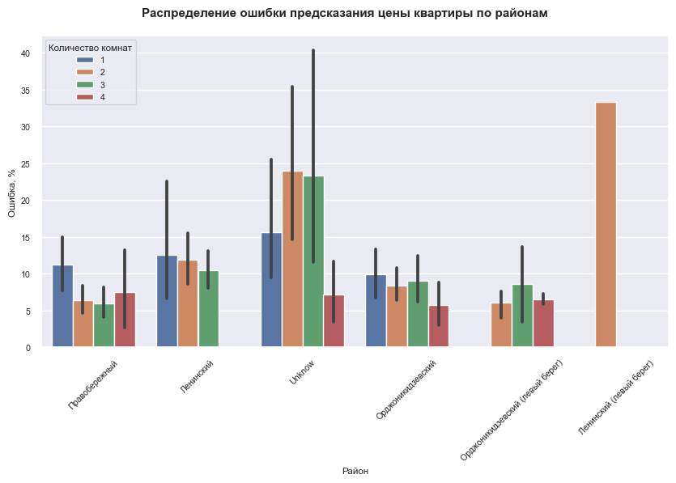

## Выводы

В данном проекте была решена задача регрессии - предсказание стоимости жилья в зависимости от параметров этого жилья.

В ходе выполнения проекта были выполнены следующие шаги:

- получение данных;
- предобработка данных;
- исследовательский анализ данных;
- обучение моделей;
- тестирование модели;
- анализ качества модели.

Итоговой моделью, показавший лучший результат на тестовой выборке, является модель градиентного бустинга CatBoostRegressor. Значение метрики RMSE равно 874.

По окончанию тестирования модель была обучена на полном датасете - тренировочная выборка плюс тестовая выборка. Метрика RMSE модели составила значение 876.4